# rodwell-ben-HOMEWORK-03

Ben Rodwell

March 18, 2019

# Problem One

#### Write a simple R function you call Z.prop.test(), that can perform one- or two-sample Z-tests for proportion data, using the following guidelines.

#### Your function should take the following arguments: p1 and n1 (no default) representing the estimated proportion and sample size (e.g., based on your sample data); p2 and n2 (both defaulting to NULL) that contain a second sample’s proportion and sample size data in the event of a two-sample test; p0 (no default) as the expected value for the population proportion; and alternative (default “two.sided”) and conf.level (default 0.95), to be used in the same way as in the function t.test().

#### When conducting a two-sample test, it should be p1 that is tested as being smaller or larger than p2 when alternative=“less” or alternative=“greater”, respectively, the same as in the use of x and y in the function t.test().

#### The function should perform a one-sample Z-test using p1, n1, and p0 if either p2 or n2 (or both) is NULL.

#### The function should contain a check for the rules of thumb we have talked about (n×π>5 and n×(1−π)>5) to ensure the validity of assuming the normal distribution in both the one- and two-sample settings. If this is violated, the function should still complete, but it should also print an appropriate warning message.

#### The function should return a list containing the following elements: Z (the test statistic), P (the appropriate p value), and CI (the two-sided CI with respect to “conf.level” around p1 in the case of a one-sample test and around p2-p1 in the case of a two-sample test). For all test alternatives (“two.sided”, “greater”, “less”), calculate symmetric CIs based on quantiles of the normal distribution rather than worrying about calculating single-limit confidence bounds.

### Code for prop test

```r
Z.prop.test <- function(p1, n1, p2 = NULL,
                        n2 = NULL, p0, alternative = "two.sided",
                        conf.level = 0.95){
  if ((n1 * p1 < 5) & (n1 * (1 - p0)< 5)) {
    warning("Assumption of normal distribution is not valid")
  }
  if (is.null(p2) | is.null(n2)){ ## z-score for one sample
    z <- (p1 - p0)/sqrt(p0 * (1 - p0)/n1)
    z
  } else { ## z-score for two samples
    pstar<-(p1*n1+p2*n2)/(n1+n2)
    z<-((p1-p2-p0)/sqrt(pstar*(1-pstar)*((1/n1)+(1/n2))))
    z
  }
  if(alternative == "two.sided" | is.null(alternative) ){
    p.upper<- 1-pnorm(abs(z), lower.tail = TRUE)
    p.lower<- pnorm(abs(z), lower.tail = FALSE)
    p<- p.upper+p.lower
  }
  if (alternative == "less" & (is.null(p2) | is.null(n2))){
    p <- (pnorm(z, lower.tail = T))
  }
  if (alternative == "greater" & (is.null(p2) | is.null(n2))){
    p <- (pnorm(z, lower.tail = F))
  }
  if (alternative == "less" & (!is.null(p2) | !is.null(n2))){
    p <- (pnorm(z, lower.tail = F))
  }
  if (alternative == "greater" & (!is.null(p2) | !is.null(n2))){
    p <- (pnorm(z, lower.tail = T))
  }

  if (is.null(p2) | is.null(n2)){ ## Confidence intervals
    alpha <- conf.level
    lower <- p1 + qnorm((1-alpha)/2) * sqrt(p1 * (1 - p1)/n1)
    upper <- p1 - qnorm((1-alpha)/2) * sqrt(p1 * (1 - p1)/n1)
    ci <- c(lower, upper)
    ci ## this is only for the one sample tests
  } else {
    lower.ci <- ((p2 - p1) - 1.96 * sqrt(((p1 * (1 - p1))/n1) + ((p2 * (1 - p2))/n2)))
    upper.ci <- ((p2 - p1) + 1.96 * sqrt(((p1 * (1 - p1))/n1) + ((p2 * (1 - p2))/n2)))
        ci <- c(lower.ci,upper.ci)  ## this is for the two sample tests
  }
  STATS <- list(P_value = p,Z_score =  z, Confidence_intervals = ci)
  return(STATS)
}
```

# PROBLEM 2

#### The comparative primate dataset we have used from Kamilar and Cooper has in it a large number of variables related to life history and body size. For this exercise, the end aim is to fit a simple linear regression model to predict longevity (MaxLongevity_m) measured in months from species’ brain size (Brain_Size_Species_Mean) measured in grams. Do the following for both longevity~brain size and log(longevity)~log(brain size).

#### Fit the regression model and, using {ggplot2}, produce a scatterplot with the fitted line superimposed upon the data. Append the the fitted model equation to your plot (HINT: use the function geom_text()).

#### Identify and interpret the point estimate of the slope (β1), as well as the outcome of the test associated with the hypotheses H0: β1=0; HA: β1≠0. Also, find a 90% CI for the slope (β1) parameter.

#### Using your model, add lines for the 90% confidence and prediction interval bands on the plot, and add a legend to differentiate between the lines.

#### Produce a point estimate and associated 90% prediction interval for the longevity of a species whose brain weight is 800 gm. Do you trust the model to predict observations accurately for this value of the explanatory variable? Why or why not?

#### Looking at your two models, which do you think is better? Why?

### Prepare the data into vectors to be used and create linear models

```r
library(tidyverse)
library(readr)
f <- "https://raw.githubusercontent.com/difiore/ADA-2019/master/KamilarAndCooperData.csv"
d <- read_csv(f, col_names = TRUE)
head(d)
```

```
## # A tibble: 6 x 44
##   Scientific_Name Family Genus Species Brain_Size_Spec~ Brain_Size_Fema~
##   <chr>           <chr>  <chr> <chr>              <dbl>            <dbl>
## 1 Allenopithecus~ Cerco~ Alle~ nigrov~             58.0             53.7
## 2 Allocebus_tric~ Cerco~ Allo~ tricho~             NA               NA
## 3 Alouatta_belze~ Ateli~ Alou~ belzeb~             52.8             51.2
## 4 Alouatta_caraya Ateli~ Alou~ caraya              52.6             47.8
## 5 Alouatta_guari~ Ateli~ Alou~ guariba             51.7             49.1
## 6 Alouatta_palli~ Ateli~ Alou~ pallia~             49.9             48.0
## # ... with 38 more variables: Brain_size_Ref <chr>,
## #   Body_mass_male_mean <dbl>, Body_mass_female_mean <dbl>,
## #   Mass_Dimorphism <dbl>, Mass_Ref <chr>, MeanGroupSize <dbl>,
## #   AdultMales <dbl>, AdultFemale <dbl>, AdultSexRatio <dbl>,
## #   Social_Organization_Ref <chr>, InterbirthInterval_d <dbl>,
## #   Gestation <dbl>, WeaningAge_d <dbl>, MaxLongevity_m <dbl>,
## #   LitterSz <dbl>, Life_History_Ref <chr>, GR_MidRangeLat_dd <dbl>,
## #   Precip_Mean_mm <dbl>, Temp_Mean_degC <dbl>, AET_Mean_mm <dbl>,
## #   PET_Mean_mm <dbl>, Climate_Ref <chr>, HomeRange_km2 <dbl>,
## #   HomeRangeRef <chr>, DayLength_km <dbl>, DayLengthRef <chr>,
## #   Territoriality <dbl>, Fruit <dbl>, Leaves <chr>, Fauna <chr>,
## #   DietRef1 <chr>, Canine_Dimorphism <dbl>, Canine_Dimorphism_Ref <chr>,
## #   Feed <dbl>, Move <dbl>, Rest <dbl>, Social <dbl>,
## #   Activity_Budget_Ref <chr>
```

### Create vectors for Longevity and Brain Size

```r
x1 <- d$Brain_Size_Species_Mean
y1 <- d$MaxLongevity_m

x2 <- log(x1)
y2 <- log(y1)
```

### Linear regression for Longevity and Brain Size

```r
lb <- lm(data = d,  y1 ~ x1)
lb
```

```
##
## Call:
## lm(formula = y1 ~ x1, data = d)
##
## Coefficients:
## (Intercept)           x1
##     248.952        1.218
```

### Linear regression for log transformed Longevity and Brain Size

```r
loglb <- lm(data = d, y2 ~ x2)
loglb
```

```
##
## Call:
## lm(formula = y2 ~ x2, data = d)
##
## Coefficients:
## (Intercept)           x2
##      4.8790       0.2341
```

#### Fit the regression model and, using {ggplot2}, produce a scatterplot with the fitted line superimposed upon the data. Append the the fitted model equation to your plot (HINT: use the function geom_text()).

### Raw data

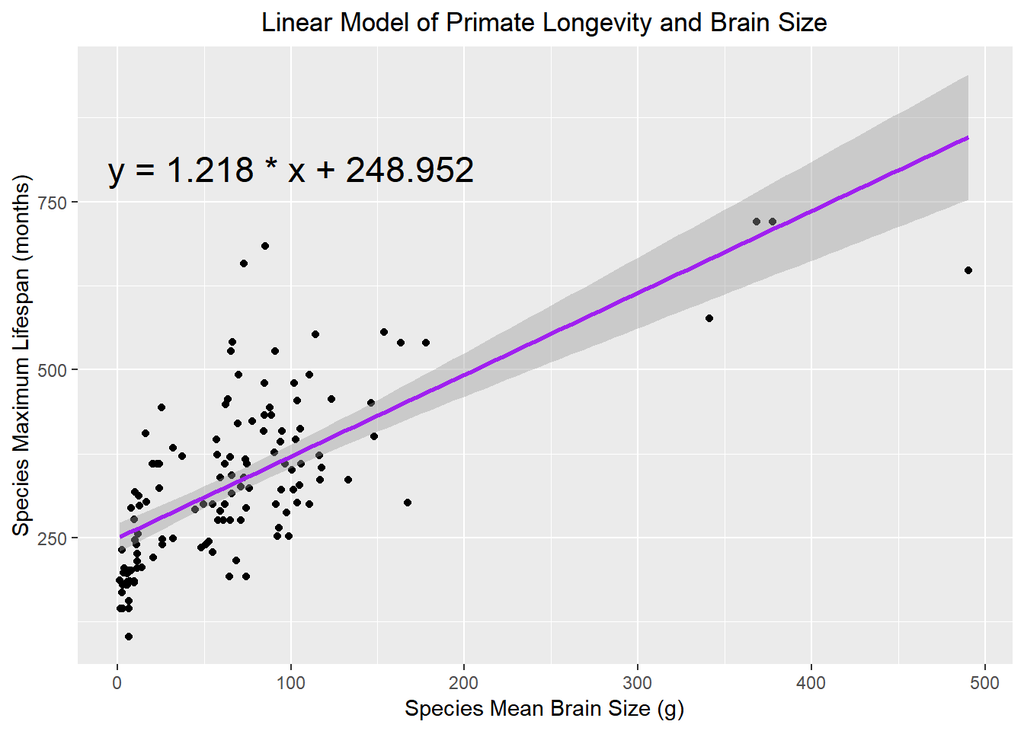

```r
g1 <- ggplot(data = d, aes(x = x1, y = y1)) + geom_point() +
  ggtitle("Linear Model of Primate Longevity and Brain Size") +
  theme(plot.title = element_text(hjust = 0.5)) +
  xlab ("Species Mean Brain Size (g)") +
  ylab ("Species Maximum Lifespan (months)") +
  geom_smooth(method = "lm", formula = y ~ x, col = "purple") +
  annotate("text", label = "y = 1.218 * x + 248.952", x = 100, y = 800, size = 6)
g1
```

### Log transformed data

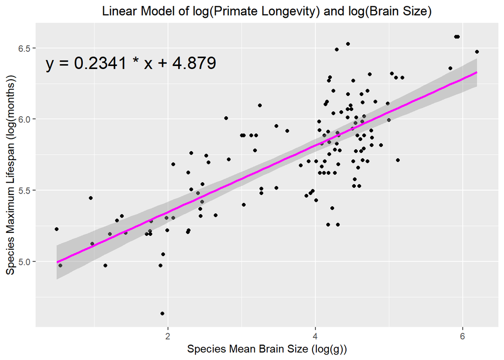

```r
g2 <- ggplot(data = d, aes(x = x2, y = y2)) + geom_point() +
  ggtitle("Linear Model of log(Primate Longevity) and log(Brain Size)") +
  theme(plot.title = element_text(hjust = 0.5)) +
  xlab ("Species Mean Brain Size (log(g))") +
  ylab ("Species Maximum Lifespan (log(months))") +
  geom_smooth(method = "lm", formula = y ~ x, col = "magenta") +
  annotate("text", label = "y = 0.2341 * x + 4.879", x = 1.5, y = 6.4, size = 6)
g2
```

#### Identify and interpret the point estimate of the slope (BETA1), as well as the outcome of the test associated with the hypotheses H0: BETA1 = 0; HA: BETA1 NOT= 0. Also, find a 90% CI for the slope (BETA1) parameter.

### Identify slope (BETA1) of the raw data

```r
slope_lb <- lb$coefficients[2]
slope_lb
```

```
##      x1
## 1.21799
```

### ID the p value of BETA1

```r
t1 <- coef(summary(lb))
t1 <- data.frame(unlist(t1))
colnames(t1) <- c("Est", "SE", "t", "p")
t1
```

```
##                   Est         SE       t            p
## (Intercept) 248.95227 11.1111143 22.4057 8.910319e-46
## x1            1.21799  0.1100879 11.0638 2.685909e-20
```

```r
t1$p[2]
```

```
## [1] 2.685909e-20
```

#### Since p is less than 0.05 we can reject the null hypothesis (H0)

### Calculate 90% confidence intervals

```r
alpha <- 0.10
t1$lmCI <- confint(lb, level = 1 - alpha)
attributes(t1$lmCI)
```

```
## $dim
## [1] 2 2
##
## $dimnames
## $dimnames[[1]]
## [1] "(Intercept)" "x1"
##
## $dimnames[[2]]
## [1] "5 %"  "95 %"
```

### Confidence Intervals of the point estimate

```r
t1[, 5]
```

```
##                    5 %      95 %
## (Intercept) 230.540738 267.36379
## x1            1.035571   1.40041
```

### Identify slope of the log transformed data

```r
slope_loglb <- loglb$coefficients[2]
slope_loglb
```

```
##        x2
## 0.2341496
```

### ID p value of BETA1

```r
t2 <- coef(summary(loglb))
t2 <- data.frame(unlist(t2))
colnames(t2) <- c("Est", "SE", "t", "p")
t2
```

```
##                   Est         SE        t             p
## (Intercept) 4.8789509 0.06907361 70.63408 3.321721e-103
## x2          0.2341496 0.01780887 13.14792  2.165214e-25
```

```r
t2$p[2]
```

```
## [1] 2.165214e-25
```

#### Since p is less than 0.05 we can reject the null hypothesis (H0)

### Calculate 90% confidence intervals

```r
alpha <- 0.10
t2$lmCI <- confint(loglb, level = 1 - alpha)
attributes(t2$lmCI)
```

```
## $dim
## [1] 2 2
##
## $dimnames
## $dimnames[[1]]
## [1] "(Intercept)" "x2"
##
## $dimnames[[2]]
## [1] "5 %"  "95 %"
```

### Confidence Intervals for the point estimate

```r
t2[,5]
```

```
##                   5 %      95 %
## (Intercept) 4.7644934 4.9934084
## x2          0.2046396 0.2636595
```

#### For both the raw and log transformed data, the p-values indicate that the BETA1 (the slope coefficient) is significantly different a null hypothesis of BETA1 equaling zero.

#### Using your model, add lines for the 90% confidence and prediction interval bands on the plot, and add a legend to differentiate between the lines.

### Raw data

```r
h_hatlb <- predict(lb, newdata = data.frame(brain = d$Brain_Size_Species_Mean))
dflb <- data.frame(cbind(d$Brain_Size_Species_Mean, d$MaxLongevity_m, h_hatlb))
names(dflb) <- c("x", "y", "yhat")
head(dflb)
```

```
##       x     y     yhat
## 1 58.02 276.0 319.6201
## 2    NA    NA       NA
## 3 52.84    NA 313.3109
## 4 52.63 243.6 313.0551
## 5 51.70    NA 311.9224
## 6 49.88 300.0 309.7056
```

```r
cilb <- predict(lb, newdata = data.frame(brain = d$Brain_Size_Species_Mean),
                interval = "confidence", level = 0.90)
head(cilb)
```

```
##        fit      lwr      upr
## 1 319.6201 306.1354 333.1047
## 2       NA       NA       NA
## 3 313.3109 299.6449 326.9768
## 4 313.0551 299.3805 326.7297
## 5 311.9224 298.2081 325.6366
## 6 309.7056 295.9081 323.5032
```

```r
dflb <- cbind(dflb, cilb)
names(dflb) <- c("x", "y", "yhat", "CIfit", "CIlwr", "CIupr")
head(dflb)
```

```
##       x     y     yhat    CIfit    CIlwr    CIupr
## 1 58.02 276.0 319.6201 319.6201 306.1354 333.1047
## 2    NA    NA       NA       NA       NA       NA
## 3 52.84    NA 313.3109 313.3109 299.6449 326.9768
## 4 52.63 243.6 313.0551 313.0551 299.3805 326.7297
## 5 51.70    NA 311.9224 311.9224 298.2081 325.6366
## 6 49.88 300.0 309.7056 309.7056 295.9081 323.5032
```

```r
pi <- predict(lb, newdata = data.frame(brain = d$Brain_Size_Species_Mean),
              interval = "prediction",
              level = 0.90)
head(pi)
```

```
##        fit      lwr      upr
## 1 319.6201 168.3750 470.8651
## 2       NA       NA       NA
## 3 313.3109 162.0496 464.5722
## 4 313.0551 161.7930 464.3172
## 5 311.9224 160.6567 463.1880
## 6 309.7056 158.4324 460.9789
```

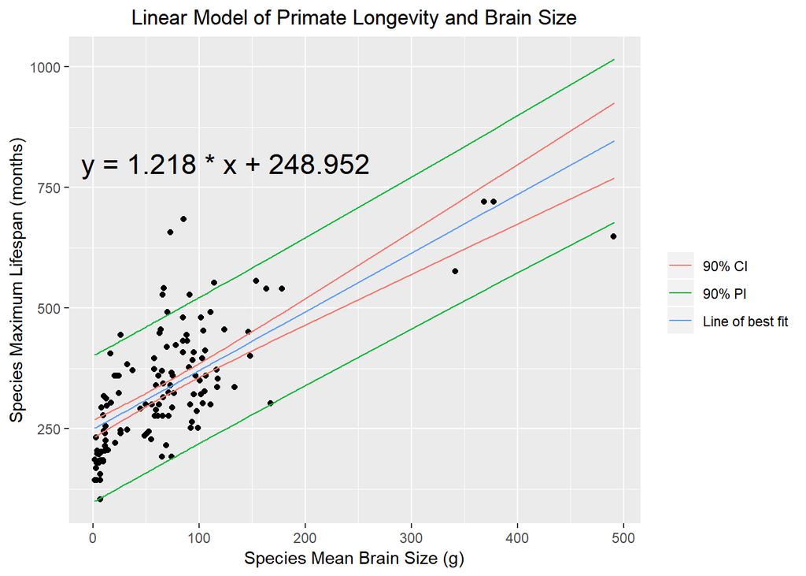

```r
lwr <- pi[,2]
upr <- pi[,3]

g1 <- ggplot(data = d, aes(x = x1, y = y1)) + geom_point() +
  ggtitle("Linear Model of Primate Longevity and Brain Size") +
  theme(plot.title = element_text(hjust = 0.5)) +
  xlab ("Species Mean Brain Size (g)") + ylab ("Species Maximum Lifespan (months)") +
  annotate("text", label = "y = 1.218 * x + 248.952", x = 125, y = 800, size = 6) +
  geom_point(alpha = 0.5) +
  geom_line(aes(x = x1, y = dflb$CIfit, color = "Line of best fit")) +
  geom_line(aes(x = x1, y = dflb$CIlwr, color = "90% CI")) +
  geom_line(aes(x = x1, y = dflb$CIupr, color = "90% CI",)) +
  geom_line(aes(x = x1, y = lwr, color = "90% PI")) +
  geom_line(aes(x = x1, y = upr, color = "90% PI")) +
  guides(color=guide_legend(title=""))
g1
```

### Log transformed data

```r
h_hatloglb <- predict(loglb, newdata = data.frame(brain = d$Brain_Size_Species_Mean))
dfloglb <- data.frame(cbind(d$Brain_Size_Species_Mean, d$MaxLongevity_m, h_hatloglb))
names(dfloglb) <- c("x", "y", "yhat")
head(dfloglb)
```

```
##       x     y     yhat
## 1 58.02 276.0 5.829783
## 2    NA    NA       NA
## 3 52.84    NA 5.807885
## 4 52.63 243.6 5.806953
## 5 51.70    NA 5.802778
## 6 49.88 300.0 5.794387
```

```r
ciloglb <- predict(loglb, newdata = data.frame(brain = d$Brain_Size_Species_Mean),
                   interval = "confidence", level = 0.90)
head(ciloglb)
```

```
##        fit      lwr      upr
## 1 5.829783 5.791675 5.867891
## 2       NA       NA       NA
## 3 5.807885 5.770504 5.845267
## 4 5.806953 5.769598 5.844308
## 5 5.802778 5.765539 5.840018
## 6 5.794387 5.757357 5.831416
```

```r
dfloglb <- cbind(dfloglb, ciloglb)
names(dfloglb) <- c("x", "y", "yhat", "CIfit", "CIlwr", "CIupr")
head(dfloglb)
```

```
##       x     y     yhat    CIfit    CIlwr    CIupr
## 1 58.02 276.0 5.829783 5.829783 5.791675 5.867891
## 2    NA    NA       NA       NA       NA       NA
## 3 52.84    NA 5.807885 5.807885 5.770504 5.845267
## 4 52.63 243.6 5.806953 5.806953 5.769598 5.844308
## 5 51.70    NA 5.802778 5.802778 5.765539 5.840018
## 6 49.88 300.0 5.794387 5.794387 5.757357 5.831416
```

```r
pilog <- predict(loglb, newdata = data.frame(brain = d$Brain_Size_Species_Mean),
                 interval = "prediction",
                 level = 0.90)
head(pilog)
```

```
##        fit      lwr      upr
## 1 5.829783 5.416322 6.243243
## 2       NA       NA       NA
## 3 5.807885 5.394491 6.221279
## 4 5.806953 5.393561 6.220344
## 5 5.802778 5.389397 6.216159
## 6 5.794387 5.381024 6.207749
```

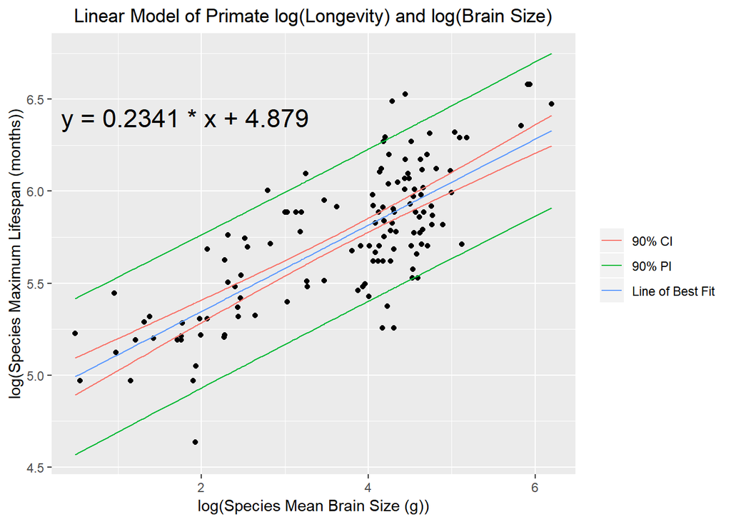

```r
lwrlog <- pilog[,2]
uprlog <- pilog[,3]

g2 <- ggplot(data = d, aes(x = x2, y = y2)) + geom_point() +
  ggtitle("Linear Model of Primate log(Longevity) and log(Brain Size)") +
  theme(plot.title = element_text(hjust = 0.5)) +
  xlab ("log(Species Mean Brain Size (g))") +
  ylab ("log(Species Maximum Lifespan (months))") +
  annotate("text", label = "y = 0.2341 * x + 4.879", x = 1.8, y = 6.4, size = 6) +
  geom_point(alpha = 0.5) + geom_line(aes(x = x2, y = lwrlog, color = "90% PI")) +
  geom_line(aes(x = x2, y = uprlog, color = "90% PI")) +
  geom_line(aes(x = x2, y = dfloglb$CIfit, color = "Line of Best Fit")) +
  geom_line(aes(x = x2, y = dfloglb$CIlwr, color = "90% CI")) +
  geom_line(aes(x = x2, y = dfloglb$CIupr, color = "90% CI")) +
  guides(color=guide_legend(title=""))
g2
```

#### Produce a point estimate and associated 90% prediction intervalvfor the longevity of a species whose brain weight is 800 gm. Do you trust the model to predict observations accurately for this value of the explanatory variable? Why or why not? Looking at your two models, which do you think is better? Why?

### Raw data preditction

```r
longest1 <- t1$Est[2] * 800 + t1$Est[1]
longest1
```

```
## [1] 1223.345
```

```r
piest1 <- predict(lb, newdata = data.frame(x1 = 800), interval = "prediction", level = 0.90)
piest1
```

```
##        fit      lwr      upr
## 1 1223.345 1021.805 1424.884
```

```r
summary(lb)
```

```
##
## Call:
## lm(formula = y1 ~ x1, data = d)
##
## Residuals:
##     Min      1Q  Median      3Q     Max
## -198.27  -61.92  -17.78   56.16  331.36
##
## Coefficients:
##             Estimate Std. Error t value Pr(>|t|)
## (Intercept) 248.9523    11.1111   22.41   <2e-16 ***
## x1            1.2180     0.1101   11.06   <2e-16 ***
## ---
## Signif. codes:  0 '***' 0.001 '**' 0.01 '*' 0.05 '.' 0.1 ' ' 1
##
## Residual standard error: 90.91 on 126 degrees of freedom
##   (85 observations deleted due to missingness)
## Multiple R-squared:  0.4928, Adjusted R-squared:  0.4887
## F-statistic: 122.4 on 1 and 126 DF,  p-value: < 2.2e-16
```

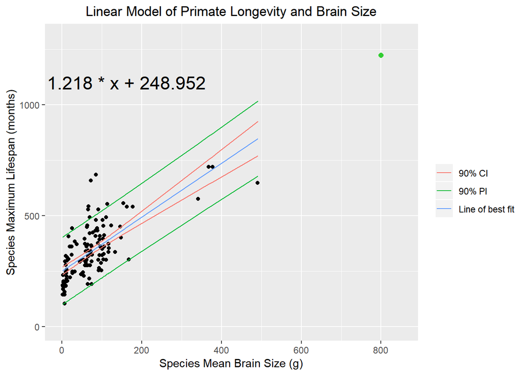

```r
## Plotting the estimated poing alongside the real data
g1 <- ggplot(data = d, aes(x = x1, y = y1)) + geom_point() +
  ggtitle("Linear Model of Primate Longevity and Brain Size") +
  theme(plot.title = element_text(hjust = 0.5)) +
  xlab ("Species Mean Brain Size (g)") + ylab ("Species Maximum Lifespan (months)") +
  annotate("text", label = "y = 1.218 * x + 248.952", x = 125, y = 1100, size = 6) +
  geom_point(alpha = 0.5) +
  geom_line(aes(x = x1, y = dflb$CIfit, color = "Line of best fit")) +
  geom_line(aes(x = x1, y = dflb$CIlwr, color = "90% CI")) +
  geom_line(aes(x = x1, y = dflb$CIupr, color = "90% CI",)) +
  geom_line(aes(x = x1, y = lwr, color = "90% PI")) +
  geom_line(aes(x = x1, y = upr, color = "90% PI")) +
  guides(color=guide_legend(title="")) +
  xlim(0, 850) + ylim(0, 1300) +
  geom_point(x = 800, y = longest1, color = "lime green", shape = 16, size = 2)
g1
```

### Log transformed data prediction

```r
longest2 <- t2$Est[2] * log(800) + t2$Est[1]
longest2
```

```
## [1] 6.44415
```

```r
piest2 <- predict(loglb, newdata = data.frame(x2 = log(800)), interval = "prediction", level = 0.90)
piest2
```

```
##       fit      lwr      upr
## 1 6.44415 6.021424 6.866876
```

```r
summary(loglb)
```

```
##
## Call:
## lm(formula = y2 ~ x2, data = d)
##
## Residuals:
##     Min      1Q  Median      3Q     Max
## -0.6955 -0.1750 -0.0097  0.1788  0.6084
##
## Coefficients:
##             Estimate Std. Error t value Pr(>|t|)
## (Intercept)  4.87895    0.06907   70.63   <2e-16 ***
## x2           0.23415    0.01781   13.15   <2e-16 ***
## ---
## Signif. codes:  0 '***' 0.001 '**' 0.01 '*' 0.05 '.' 0.1 ' ' 1
##
## Residual standard error: 0.2485 on 126 degrees of freedom
##   (85 observations deleted due to missingness)
## Multiple R-squared:  0.5784, Adjusted R-squared:  0.5751
## F-statistic: 172.9 on 1 and 126 DF,  p-value: < 2.2e-16
```

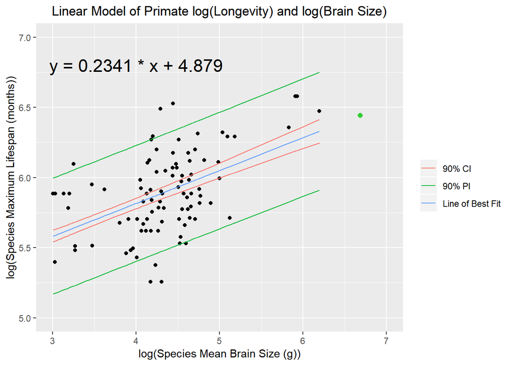

```r
g2 <- ggplot(data = d, aes(x = x2, y = y2)) + geom_point() +
  ggtitle("Linear Model of Primate log(Longevity) and log(Brain Size)") +
  theme(plot.title = element_text(hjust = 0.5)) +
  xlab ("log(Species Mean Brain Size (g))") +
  ylab ("log(Species Maximum Lifespan (months))") +
  annotate("text", label = "y = 0.2341 * x + 4.879", x = 4, y = 6.8, size = 6) +
  geom_point(alpha = 0.5) + geom_line(aes(x = x2, y = lwrlog, color = "90% PI")) +
  geom_line(aes(x = x2, y = uprlog, color = "90% PI")) +
  geom_line(aes(x = x2, y = dfloglb$CIfit, color = "Line of Best Fit")) +
  geom_line(aes(x = x2, y = dfloglb$CIlwr, color = "90% CI")) +
  geom_line(aes(x = x2, y = dfloglb$CIupr, color = "90% CI")) +
  guides(color=guide_legend(title="")) +
  xlim(3, 7) + ylim (5, 7) +
  geom_point(x = log(800), y = longest2, color = "lime green", shape = 16, size = 2)
g2
```

#### When looking at the the raw data versus the log tansformed data, the log transformed data appears to generate a better predictive model. The log transformed data provides a higher r-squared value, likely because it somewhat normalizes the data because brain size is not normally distributed in this data set. Because of the low fit of the models to the data I would be hesitant to take the predicted values as being highly accurate. Also when looking at the raw data further, most of the measured data points come from the lower end of the measured distribution for (<100 grams), and the dataset contains relatively fewer data points from the higher end of the distribution. This might mean that the dataset is biased towards species of smaller body size and is not entirely representative of the relationship between brain size and longevity, especially for species with larger brains.